# tresthor *Package R pour la prévision économique* Utilisation d’Opale sur R

*par Anissa Saumtally*

*Ce guide fait partie d’une série de trois guides sur tresthor :*

- Le [guide de l’utilisateur](https://www.tresor.economie.gouv.fr/Content/other/Opale/manuel_tresthor.html) présente en détail l’ensemble des fonctionnalités du package.
- Le [guide d’utilisation du modèle Opale](https://www.tresor.economie.gouv.fr/Content/other/Opale/manuel_opale_r.html) en R par tresthor.
- Le [guide appliqué de prévision](https://www.tresor.economie.gouv.fr/Content/other/Opale/application_tresthor_modele_uk.html) par tresthor avec un modèle simplifié sur le Royaume-Uni.

Ce guide vise à permettre une prise en main rapide d’Opale sous R avec le package `tresthor`. Pour plus de détails techniques concernant le fonctionnement du package, se référer au [manuel de l’utilisateur](https://www.tresor.economie.gouv.fr/Content/other/manuel_tresthor). Un exemple du processus de prévision complet, de la récupération des données à la projection sur un modèle simple est proposé dans [l’exemple UK](https://www.tresor.economie.gouv.fr/Content/other/Opale/application_tresthor_modele_uk.html). Les lignes de commandes proposées ici peuvent directement être utilisées en l’état du moment que le package `tresthor` est installé.

# 1 Opale : les ressources mises à disposition

Opale est le modèle macroéconomique de la DG Trésor utilisé pour les prévisions de croissance à horizon 2-3 ans pour les budgets des lois de finances et programmes de stabilité. Il s’agit d’un modèle composé d’environ 500 équations pour représenter l’économie française à partir d’équations économétriques et comptables.

La documentation complète sur la construction de ce modèle est disponible sur le [site de la DG Trésor](https://www.tresor.economie.gouv.fr/Articles/2017/05/19/la-maquette-de-prevision-opale-2017).

```r
sample_n(dictionnaire_variables_opale,size = 10)
```

|  | code | categorie | nom_long | precision | nom_court | nature |
| --- | --- | --- | --- | --- | --- | --- |
| coefp2az7_ch | coefp2az7_ch | Coefficient technique | Consommations intermédiaires branches agricoles en volume chaîné |  | Consommations intermédiaires branches agricoles en volume chaîné |  |
| td_p7_az0 | td_p7_az0 | Variable | Déflateur des importations de biens agricoles (prix année N-1) | (CVS-CJO) | Déflateur des importations de biens agricoles | prix année N-1 |
| td_dempub3 | td_dempub3 | Variable | Demande publique en valeur | (CVS-CJO) | Demande publique | valeur |
| mup6dimhc25 | mup6dimhc25 | Coefficient économétrique | Prix des importations de biens manufacturés hors carburants raffinés - force de rappel | force de rappel | Prix des importations de biens manufacturés hors carburants raffinés - force de rappel |  |
| coefp2eoq5_ch | coefp2eoq5_ch | Coefficient technique | Déflateur de consommations intermédiaires branches non marchandes (prix chaînés) |  | Déflateur de consommations intermédiaires branches non marchandes (prix chaînés) |  |
| mup2bmna5 | mup2bmna5 | Coefficient économétrique | Prix des consommations intermédiaires BMNA - force de rappel | force de rappel | Prix des consommations intermédiaires BMNA - force de rappel |  |
| td_p6_c27 | td_p6_c27 | Variable | Exportations de carburants raffinés en volume | (CVS-CJO) | Exportations de carburants raffinés | volume |
| taux_epargne_s14 | taux_epargne_s14 | Variable | Taux d'épargne des ménages |  | Taux d'épargne des ménages |  |
| wdcst | wdcst | Coefficient économétrique | Wage drift - constante | constante | Wage drift - constante |  |
| empb1vol0 | empb1vol0 | Coefficient économétrique | Emploi (estel, fin de trimestre) - Valeur ajoutée BMNA en volume | Valeur ajoutée BMNA en volume | Emploi (estel, fin de trimestre) - Valeur ajoutée BMNA en volume |  |

# 2 Préparation

Pour initialiser les calculs d’Opale, on commence par créer le modèle et charger les données.

## 2.1 Création de l’objet modèle

La fonction `create_model()` permet de créer l’objet modèle (de la classe `thoR.model`) dans l’environnement de travail. Pour cet exemple nous choisissons de ne pas utiliser l’option Rcpp (voir le [manuel de l’utilisateur](https://www.tresor.economie.gouv.fr/Content/other/Opale/manuel_tresthor.html) pour plus de d’informations), cependant étant donnée la taille du modèle, si la projection du modèle devait se faire à un horizon supérieur à 2 ans, l’option Rcpp permettrait d’obtenir des gains de temps significatifs. Il convient ensuite de sauvegarder l’objet pour réutilisation ultérieure sans avoir à recréer le modéle.

```r
library(tresthor)
### Opale : création de l'objet thoR.model
create_model(model_name = "Opale",
             model_source = system.file("Opale","opale.txt",package = "tresthor"),rcpp = FALSE)

### Si Rcpp doit être utilisé :
# create_model(model_name = "Opale",
#              model_source = system.file("Opale","opale.txt",package = "tresthor"),rcpp = TRUE)

save_model(Opale)

### Le modèle sera accessible par la suite par la fonction suivante:
load_model("Opale")
```

Un objet `Opale` est alors crée dans l’environnement. Il peut être interrogé par les fonctions `var_info_model()` et `equation_info_model()` :

```r
var_info_model("td_p3m_d7_ch",Opale)
```

```
##
##
##  INFORMATION ON td_p3m_d7_ch
##
##  TYPE:
## endogenous, heart
##
##  EQUATIONS:
## td_p3m_d0,td_p3m_d7,td_p3m_d3,contpib7_td_p3m_d,conso_m
##
##  EQUATIONS FORMULAS:
## eq_029 td_p3m_d0 : td_p3m_d0=(lag(td_p3m_d3,-(trim))+lag(td_p3m_d3,-(trim+1))+lag(td_p3m_d3,-(trim+2))+lag(td_p3m_d3,-(trim+3)))/(lag(td_p3m_d7_ch,-(trim))+lag(td_p3m_d7_ch,-(trim+1))+lag(td_p3m_d7_ch,-(trim+2))+lag(td_p3m_d7_ch,-(trim+3)))
##
##  eq_091 td_p3m_d7 : td_p3m_d7=td_p3m_d7_ch*td_p3m_d0
##
##  eq_154 td_p3m_d3 : td_p3m_d3=td_p3m_d7_ch*td_p3m_d5_ch/100
##
##  eq_234 contpib7_td_p3m_d : contpib7_td_p3m_d=(trim1)*(100*(td_p3m_d7/td_pib0-(lag(td_p3m_d7,-1)/lag(td_pib0,-1)))*1/lag(td_pib7_ch,-1)-100*(td_p3m_d0/td_pib0-(lag(td_p3m_d0,-1)/lag(td_pib0,-1)))*(lag(td_p3m_d7_ch,-1)+lag(td_p3m_d7_ch,-2)+lag(td_p3m_d7_ch,-3)+lag(td_p3m_d7_ch,-4))/(lag(td_pib7_ch…
##
##  eq_430 conso_m : delta(1,log(td_p3m_d7_ch))=p3md7cst+p3md7balpos*balpos+p3md7balneg*balneg+p3md7juppos*juppos+p3md7jupneg*jupneg+p3md7filneg*filneg+p3md7indic1999q3*indic1999q3+p3md7rdbr0*delta(1,log(rdb_hd42))+p3md7rdbr1*delta(1,log(lag(rdb_hd42,-1)))+p3md7tcho0*delta(1,tcho)+p3md7vs0*delta(1,t…
##
##
##
```

```r
equation_info_model("invest_m",Opale)
```

```
##
##
##  EQUATION ID: eq_436 | NAME : invest_m |  PART : prologue
##
##  ENDOGENOUS VARIABLES:
## td_p51m_d7_ch, pimmo_p51m_d5, rdb_p51m_d5
##
##  EXOGENOUS VARIABLES:
## p51m_d7_ch_residu, tcho
##
##  COEFFICIENT VARIABLES:
##
##
##  FORMULAS:
##  delta(1,log(td_p51m_d7_ch))=0.0000208+0.610246*(delta(1,log(lag(td_p51m_d7_ch,-1)))-delta(1,lag(p51m_d7_ch_residu,-1)))+0.208469*delta(1,log(pimmo_p51m_d5))-0.007541*delta(1,tcho)-0.078822*(log(lag(td_p51m_d7_ch,-1))-lag(p51m_d7_ch_residu,-1)-log(lag(rdb_p51m_d5,-1))-(2.159988+0.397879*log(lag(p…
```

## 2.2 Chargement des données

On charge les données et crée une base `donnees_source` à partir du jeu de données du package, puis on vérifie que toutes les variables du modèle sont présentes.

```r
donnees_source <- readRDS(system.file("Opale","donnees_opale.rds",package = "tresthor")) %>% filter (date <= as.Date("2019-10-01"))

data_model_checks(Opale,donnees_source)
```

```
## The following coefficient variables are missing from the database.
##   [1] "d5s14e3cst"          "d5s14e3dummy98"      "d5s14e3rdbact0"
##   [4] "d62s14r3cst"         "d62s14r3cst_alt"     "d62s14r3empsd0t_alt"
##   [7] "empar1"              "empar2"              "empb1vol0"
##  [10] "empcst"              "ipcc0"               "ipcsjar1"
##  [13] "ipcsjindgal"         "ipcsjmu1"            "ipcsjmu2"
##  [16] "ipcvolar3"           "ipcvolbaril0"        "ipcvolbaril2"
##  [19] "ipcvolcst"           "mud5s14e3"           "mud62s14r3a"
##  [22] "mud62s14r3b"         "mud62s14r3t_alt"     "muemp"
##  [25] "muipcvol"            "mup1mid5"            "mup2bmna5"
##  [28] "mup3md7"             "mup51sd5"            "mup6c25"
##  [31] "mup6dim5"            "mup6dimhc25"         "mup6serv7"
##  [34] "mup7c25"             "mup7de5"             "mup7de7"
##  [37] "mup7dim5"            "mup7dimhc25"         "mup7serv7"
##  [40] "musmb"               "musmbech"            "musmbpva"
```

[output cut: 32 more lines]

```
## [1] FALSE
```

La fonction `data_model_checks()` nous indique qu’il manque les coefficients à la base de données.

## 2.3 Ajouts des coefficients

On ajoute donc les coefficients avec la fonction `add_coeffs()`.

```r
coeffs_opale <- readRDS(system.file("Opale","coefficients_opale.rds",package = "tresthor"))
names(coeffs_opale)
```

```
## [1] "value" "name"
```

```r
## les noms des coefficients apparaissent dans la deuxième colonne, et les valeurs dans la première.

donnees_completes <- add_coeffs(coeffs_opale,donnees_source,
                                pos.coeff.name = 2, pos.coeff.value = 1)
rownames(donnees_completes)<-donnees_completes$date

data_model_checks(Opale,donnees_completes)
```

```
## [1] TRUE
```

Les données et le modèle sont prêts à être utilisés par le solveur.

# 3 Utilisation du solveur

## 3.1 Test du solveur sur l’année 2019

Les données présentes dans la base sont complètes. Les résidus sont déjà calculés, faire tourner le solveur devrait donc générer les mêmes valeurs pour les variables endogènes :

```r
## On définit les dates de début et fin de l'année 2019 au même format que la colonne 'date' de la base de données
T12019 <- as.Date("2019-01-01") #1er trimestre 2019
T42019 <- as.Date("2019-10-01") #4eme trimestre 2019

dates_prev <- as.character(donnees_completes$date[which(donnees_completes$date >= T12019 & donnees_completes$date <= T42019) ])

donnees_tests <- thor_solver(Opale, first_period = T12019, last_period = T42019,
                             database = donnees_completes,index_time = 'date',rcpp = FALSE)
```

```r
## On calcule les écarts sur certaines composantes du PIB endogènes au modèle :
composantes_pib_test<-c("td_pib7_ch","td_p3m_d7_ch","td_p51s_d7_ch","td_p6_d7_ch","td_p7_d7_ch")

## Il s'agit en volume chaînés du PIB, la consommation des ménages, l'investissement des entreprises, des exports et des imports.
ecarts <-cbind(date = donnees_tests$date, abs(donnees_tests[,composantes_pib_test] - donnees_completes[,composantes_pib_test] )) %>%  filter(date >= T12019 & date <= T42019) %>% mutate_if(is.numeric,function(x)round(x,8))

ecarts
```

| date | td_pib7_ch | td_p3m_d7_ch | td_p51s_d7_ch | td_p6_d7_ch | td_p7_d7_ch |
| --- | --- | --- | --- | --- | --- |
| 2019-01-01 | 0 | 0 | 0 | 0 | 0 |
| 2019-04-01 | 0 | 0 | 0 | 0 | 0 |
| 2019-07-01 | 0 | 0 | 0 | 0 | 0 |
| 2019-10-01 | 0 | 0 | 0 | 0 | 0 |

Si des écarts infimes subsistent, cela est dû au recalcul de ces variables par le solveur qui est un calcul d’une solution approchée convergente.

## 3.2 Application : Retour sur l’année 2019 par Opale

L’exemple précédent intégrait directement les résidus calculés au préalable pour assurer l’équilibre des valeurs observées (les données Insee) sur l’ensemble du modèle. De ce fait, la prévision par le solveur retrouvait les valeurs effectivement observées.

Afin de pouvoir utiliser le modèle Opale à des fins plus analytiques, l’exemple suivant propose une simulation de l’année 2019 par Opale en supposant que les variables exogènes sont effectivement connues.

Nous souhaitons savoir ce que les équations comportementales d’Opale aurait prévu avec ces données[^2]. Pour ce faire, il faut mettre à zéro les variables résiduelles. Cependant, comme les équations d’Opale sont modélisées en taux de croissance (en *diff(log)*), c’est la différence sur une période de des variables résiduelles correspondant aux variables expliquées des équations qu’il faut neutraliser. Cela revient à geler les résidus sur leur dernière valeur avant la période de projection :

```r
## on récupère la liste des résidus exogènes (dans opale les variables residuelles contiennent "_residu")
residus_exo <- Opale@exo_list[grep("_residu",Opale@exo_list)]
donneesT42018 <- as.vector(donnees_completes["2018-10-01",residus_exo] )


## Sur la période de prévision, on fixe la valeur de ces résidus à leur valeur du T4 2018
donnees_res_nuls<-donnees_completes
donnees_res_nuls[dates_prev,residus_exo]<-donneesT42018
```

On fait tourner le solveur avec ces nouvelles données modifiées.

```r
donnees_prev <- thor_solver(Opale, first_period = T12019, last_period = T42019,
                             database = donnees_res_nuls,index_time = 'date')
```

Pour voir ce que cela donne en prévision sur quelques composantes du PIB (taux de croissance en %):

```r
composantes_pib<-c("td_pib7_ch","td_p3m_d7_ch","td_p3g_d7_ch","td_p51s_d7_ch","td_p6_d7_ch","td_p7_d7_ch")

composantes_pib_noms<- dictionnaire_variables_opale[composantes_pib,"nom_court"]

donnees_prev_resume <- donnees_prev[,c('date',composantes_pib)] %>% mutate_if(is.numeric,function(x){round(100*(x/lag(x)-1),2)}) %>% filter(date>=as.Date("2018-01-01") & date<=T42019 )
rownames(donnees_prev_resume)<- donnees_prev_resume$date

donnees_prev_resume<-donnees_prev_resume%>% select(-date) %>% t() %>% as.data.frame()
row.names(donnees_prev_resume)<-composantes_pib_noms
colnames(donnees_prev_resume)<-reformat_date(as.Date(colnames(donnees_prev_resume))) %>% str_replace("Q","T")

donnees_completes_resume <- donnees_completes[,c('date',composantes_pib)] %>% mutate_if(is.numeric,function(x){round(100*(x/lag(x)-1),2)}) %>% filter(date>=as.Date("2018-01-01") & date<=T42019 )
rownames(donnees_completes_resume)<- donnees_completes_resume$date

donnees_completes_resume <-donnees_completes_resume %>% select(-date) %>% t() %>% as.data.frame()

row.names(donnees_completes_resume)<-composantes_pib_noms
colnames(donnees_completes_resume)<-reformat_date(as.Date(colnames(donnees_completes_resume))) %>% str_replace("Q","T")

donnees_ecarts <- donnees_prev_resume - donnees_completes_resume
```

|  | 2018T1 | 2018T2 | 2018T3 | 2018T4 | 2019T1 | 2019T2 | 2019T3 | 2019T4 |
| --- | --- | --- | --- | --- | --- | --- | --- | --- |
| PIB | 0.03 | 0.38 | 0.43 | 0.61 | 0.48 | 0.36 | 0.12 | 0.09 |
| Consommation des ménages | 0.24 | -0.21 | 0.26 | 0.56 | 0.47 | 0.53 | 0.13 | 0.60 |
| Consommation publique | -0.07 | 0.31 | 0.01 | 0.47 | 0.09 | 0.31 | 0.37 | 0.25 |
| FBCF des entreprises non financières | 0.03 | 1.55 | 1.04 | 0.13 | 1.04 | 0.68 | 0.09 | -0.24 |
| Exportations totales | 0.51 | 0.91 | 0.56 | 0.84 | 0.72 | 0.33 | 0.27 | -0.26 |
| Importations totales | 0.51 | 1.05 | -0.73 | 1.16 | 1.50 | 1.18 | 0.01 | -0.52 |

Et ce que cela donne en écart par rapport aux taux de croissances observés :

|  | 2018T1 | 2018T2 | 2018T3 | 2018T4 | 2019T1 | 2019T2 | 2019T3 | 2019T4 |
| --- | --- | --- | --- | --- | --- | --- | --- | --- |
| PIB | 0 | 0 | 0 | 0 | -0.15 | -0.19 | -0.06 | 0.42 |
| Consommation des ménages | 0 | 0 | 0 | 0 | -0.33 | 0.15 | -0.28 | 0.29 |
| Consommation publique | 0 | 0 | 0 | 0 | 0.00 | 0.00 | 0.00 | 0.00 |
| FBCF des entreprises non financières | 0 | 0 | 0 | 0 | 0.92 | -0.68 | -0.99 | -0.19 |
| Exportations totales | 0 | 0 | 0 | 0 | -0.75 | 0.69 | 1.15 | 1.34 |
| Importations totales | 0 | 0 | 0 | 0 | -0.48 | 1.05 | 0.42 | 0.50 |

# 4 Analyses complémentaires : exemple de l’équation de consommation des ménages

Afin de mieux comprendre les dynamiques économiques, on peut utiliser les équations des modèles pour effectuer une relecture des données obtenues. Cela permet de mesurer la capacité de l’équation du modèle à prévoir les évolutions de la variable.

## 4.1 Préparation de l’équation

Dans un premier temps, on extrait l’équation d’intérêt du modèle (ici `conso_m`, soit l’équation de consommation des ménages) et on spécifie la variable endogène qui va faire l’objet des analyses (ici `td_p3m_d7_ch`, soit la consommation des ménages en volumes chaînés). Cela va créer un objet `thoR.equation` appelé `conso_m` dans l’environnement.

```r
equation_from_model("conso_m",Opale,"td_p3m_d7_ch")
```

```
##
## Equation variables identified :
## balneg balpos filneg indic1999q3 jupneg juppos mup3md7 p3m_d7_ch_residu p3md7balneg p3md7balpos p3md7cst p3md7filneg p3md7indic1999q3 p3md7jupneg p3md7juppos p3md7rdbr0 p3md7rdbr1 p3md7tcho0 p3md7vs0 rdb_hd42 tcho td_p3m_d7_ch tempvs1
##  Exogenous variables :
## balneg balpos filneg indic1999q3 jupneg juppos p3m_d7_ch_residu rdb_hd42 tcho tempvs1
##  RHS of equation appears to be ok for econometric estimations with the current coefficient list.
```

### 4.1.1 Variables des l’équation dans le dictionnaire

L’équation de consommation des ménages est écrite dans le modèle avec des noms de variables peu explicites au premier abords :

```r
variables_eq_conso <- c(conso_m@endogenous,conso_m@exogenous,conso_m@coefflist )
cat (variables_eq_conso)
```

```
## td_p3m_d7_ch balneg balpos filneg indic1999q3 jupneg juppos p3m_d7_ch_residu rdb_hd42 tcho tempvs1 p3md7cst p3md7balpos p3md7balneg p3md7juppos p3md7jupneg p3md7filneg p3md7indic1999q3 p3md7rdbr0 p3md7rdbr1 p3md7tcho0 p3md7vs0 mup3md7
```

Pour avoir plus d’informations, on peut se référer au dictionnaire des variables d’opale du package :

```r
dictionnaire_variables_opale %>% filter(code %in% all_of(variables_eq_conso), categorie != "Coefficient économétrique")
```

|  | code | categorie | nom_long | precision | nom_court | nature |
| --- | --- | --- | --- | --- | --- | --- |
| balneg | balneg | Indicatrice ou tendance | Report d’achat et le contrecoup liés aux mesures Balladur |  | Report d’achat et le contrecoup liés aux mesures Balladur |  |
| balpos | balpos | Indicatrice ou tendance | Anticipation d’achat lié à l’arrêt des mesures Balladur |  | Anticipation d’achat lié à l’arrêt des mesures Balladur |  |
| filneg | filneg | Indicatrice ou tendance | Sortie du dispositif de prime à la casse |  | Sortie du dispositif de prime à la casse |  |
| indic1999q3 | indic1999q3 | Indicatrice ou tendance | T3 1999 |  | T3 1999 |  |
| jupneg | jupneg | Indicatrice ou tendance | Sortie du dispositif Juppé |  | Sortie du dispositif Juppé |  |
| juppos | juppos | Indicatrice ou tendance | Entrée en vigueur du dispositif Juppé |  | Entrée en vigueur du dispositif Juppé |  |
| p3m_d7_ch_residu | p3m_d7_ch_residu | Résidu | Consommation des ménages en volume |  | Consommation des ménages en volume |  |
| rdb_hd42 | rdb_hd42 | Variable | Revenu disponible brut des ménages hors dividendes |  | Revenu disponible brut des ménages hors dividendes |  |
| tcho | tcho | Variable | Taux de chômage (France métropolitaine) |  | Taux de chômage (France métropolitaine) |  |
| td_p3m_d7_ch | td_p3m_d7_ch | Variable | Consommation des ménages en volume chaîné | (CVS-CJO) | Consommation des ménages | volume chaîné |

[output cut: 1 more lines]

## 4.2 Réestimation des coefficents du court-terme de l’équation

Sans modifier la spécification de l’équation, et en conservant la partie de long terme de l’équation (ici la contrainte de l’élasticité unitaire de la consommation par rapport au revenu à long terme), on peut tester une autre estimation des coefficients en changeant la période d’estimation. La fonction `quick_estim()` permet de calculer par les MCO les nouveaux coefficients et de les ajouter à la base de données.

```r
### il faut remettre à 0 les résidus pour pouvoir estimer les coefficients

donnees_nouveaux_coefficients <-donnees_completes %>%  mutate(p3m_d7_ch_residu=0) %>%
                                quick_estim(thor_equation = conso_m,database =.,
                                            estim_start = as.Date("1990-01-01"),
                                            estim_end = as.Date("2018-10-01"))
```

On peut visualiser les écarts avec l’ancienne estimation:

```r
### ecarts des coefficients
as.data.frame(t(donnees_completes[1,conso_m@coefflist] - donnees_nouveaux_coefficients[1,conso_m@coefflist]) )%>% rename(ecarts = 1)
```

|  | ecarts |
| --- | --- |
| p3md7cst | -0.0156458953 |
| p3md7balpos | 0.0001141589 |
| p3md7balneg | -0.0001070961 |
| p3md7juppos | 0.0003876122 |
| p3md7jupneg | -0.0002026919 |
| p3md7filneg | -0.0002139154 |
| p3md7indic1999q3 | -0.0002728971 |
| p3md7rdbr0 | -0.0085113576 |
| p3md7rdbr1 | -0.0084084423 |
| p3md7tcho0 | -0.0005995243 |

[output cut: 2 more lines]

*Ces écarts ne sont pas très importants, nous conservons les valeurs originales des coefficients.*

Pour visualiser la formule de l’équation avec les valeurs numériques de coefficients, on utilise `formula_with_coeffs()` :

```r
formula_with_coeffs(formula = conso_m,database = donnees_completes)
```

```
## delta(1,log(td_p3m_d7_ch))=0.5978+0.0099*balpos+-0.0148*balneg+0.0116*juppos+-0.0124*jupneg+-0.0146*filneg+0.0139*indic1999q3+0.1361*delta(1,log(rdb_hd42))+0.1218*delta(1,log(lag(rdb_hd42,-1)))+-0.0062*delta(1,tcho)+-0.0008*delta(1,tempvs1)+-0.133*(log(lag(td_p3m_d7_ch,-1))-lag(p3m_d7_ch_residu,-…
```

Et pour l’avoir en $\LaTeX$ :

```r
formule_complete_latex <- formula_latex(formula_with_coeffs(formula = conso_m,database = donnees_completes))
```

```
## delta(1,log(td_p3m_d7_ch))=0.5978+0.0099*balpos+-0.0148*balneg+0.0116*juppos+-0.0124*jupneg+-0.0146*filneg+0.0139*indic1999q3+0.1361*delta(1,log(rdb_hd42))+0.1218*delta(1,log(lag(rdb_hd42,-1)))+-0.0062*delta(1,tcho)+-0.0008*delta(1,tempvs1)+-0.133*(log(lag(td_p3m_d7_ch,-1))-lag(p3m_d7_ch_residu,-…
```

```r
cat(formule_complete_latex)
```

```
## \Delta_{1}( \mathit{log(} \textbf{td_p3m_d7_ch}_{t} ))=0.5978+0.0099* \textbf{balpos}_{t} -0.0148* \textbf{balneg}_{t} +0.0116* \textbf{juppos}_{t} -0.0124* \textbf{jupneg}_{t} -0.0146* \textbf{filneg}_{t} +0.0139* \textbf{indic1999q3}_{t} +0.1361* \Delta_{1}( \mathit{log(} \textbf{rdb_hd42}_{t} …
```

*Etant donné la longueur de l’équation il conviendrait d’ajouter des sauts de ligne avec* `\n` *dans la formule de l’équation ou bien directement dans le code LaTex obtenu avec des* `\\`. *Voici ce que cela donne sinon :*

$\Delta_{1}( \mathit{log(} \textbf{td_p3m_d7_ch}_{t} ))=0.5978+0.0099* \textbf{balpos}_{t} -0.0148* \textbf{balneg}_{t} +0.0116* \textbf{juppos}_{t} -0.0124* \textbf{jupneg}_{t} -0.0146* \textbf{filneg}_{t} +0.0139* \textbf{indic1999q3}_{t} +0.1361* \Delta_{1}( \mathit{log(} \textbf{rdb_hd42}_{t} ))+0.1218* \Delta_{1}( \mathit{log(} \textbf{rdb_hd42}_{t-1} ))-0.0062* \Delta_{1}( \textbf{tcho}_{t} )-0.0008* \Delta_{1}( \textbf{tempvs1}_{t} )-0.133*( \mathit{log(} \textbf{td_p3m_d7_ch}_{t-1} )- \textbf{p3m_d7_ch_residu}_{t-1} -1* \mathit{log(} \textbf{rdb_hd42}_{t-1} ))+ \Delta_{1}( \textbf{p3m_d7_ch_residu}_{t} )$

## 4.3 Observé vs Simulé

Une première approche consiste à calculer, à partir d’une date choisie, le simulé, c’est à dire la valeur de l’endogène telle que prédite par le modèle, et de le comparer à l’observé. L’observé correspond ici aux données Insee.

Comme la fonction remet à zéro les résidus puis les recalcule, il faut indiquer le nom de la variables résiduelle dans l’équation pour que la fonction puisse détecter cette variable dans la formule.

```r
## on simule l'équation à partir du T1 2018
T12018 <- as.Date("2018-01-01")

simule <- simulate_equation(conso_m,database = donnees_completes,
                            start_sim = T12018, end_sim = T42019,
                            residual_var = "p3m_d7_ch_residu")
rownames(simule) <- simule$date
```

|  | date | observed | balneg | balpos | filneg | indic1999q3 | jupneg | juppos | p3m_d7_ch_residu | rdb_hd42 | tcho | tempvs1 | p3md7cst | p3md7balpos | p3md7balneg | p3md7juppos | p3md7jupneg | p3md7filneg | p3md7indic1999q3 | p3md7rdbr0 | p3md7rdbr1 | p3md7tcho0 | p3md7vs0 | mup3md7 | simulated | residual | g_obs | g_sim | dlog_obs | … |
| --- | --- | --- | --- | --- | --- | --- | --- | --- | --- | --- | --- | --- | --- | --- | --- | --- | --- | --- | --- | --- | --- | --- | --- | --- | --- | --- | --- | --- | --- | --- |
| 2017-07-01 | 2017-07-01 | 295335 | 0 | 0 | 0 | 0 | 0 | 0 | 0 | 3358.712 | 9.5 | -0.3700000 | 0.5978039 | 0.009871362 | -0.01475681 | 0.01163533 | -0.01244142 | -0.01461924 | 0.01391638 | 0.1361404 | 0.1218202 | -0.0062436 | -0.0008268894 | -0.1330467 | 295335.0 | 0.0000000000 | 0.005590872 | 0.0055908721 | 0.005575301 | … |
| 2017-10-01 | 2017-10-01 | 296000 | 0 | 0 | 0 | 0 | 0 | 0 | 0 | 3375.199 | 9.0 | 0.2400000 | 0.5978039 | 0.009871362 | -0.01475681 | 0.01163533 | -0.01244142 | -0.01461924 | 0.01391638 | 0.1361404 | 0.1218202 | -0.0062436 | -0.0008268894 | -0.1330467 | 296000.0 | 0.0000000000 | 0.002251680 | 0.0022516803 | 0.002249149 | … |
| 2018-01-01 | 2018-01-01 | 296713 | 0 | 0 | 0 | 0 | 0 | 0 | 0 | 3349.870 | 9.2 | -0.2000000 | 0.5978039 | 0.009871362 | -0.01475681 | 0.01163533 | -0.01244142 | -0.01461924 | 0.01391638 | 0.1361404 | 0.1218202 | -0.0062436 | -0.0008268894 | -0.1330467 | 296370.8 | 0.0011540536 | 0.002408784 | 0.0012526176 | 0.002405887 | … |
| 2018-04-01 | 2018-04-01 | 296096 | 0 | 0 | 0 | 0 | 0 | 0 | 0 | 3363.128 | 9.1 | 1.2000000 | 0.5978039 | 0.009871362 | -0.01475681 | 0.01163533 | -0.01244142 | -0.01461924 | 0.01391638 | 0.1361404 | 0.1218202 | -0.0062436 | -0.0008268894 | -0.1330467 | 296514.2 | -0.0014113450 | -0.002079451 | 0.0004839001 | -0.002081616 | … |
| 2018-07-01 | 2018-07-01 | 296878 | 0 | 0 | 0 | 0 | 0 | 0 | 0 | 3373.306 | 9.0 | 1.5000000 | 0.5978039 | 0.009871362 | -0.01475681 | 0.01163533 | -0.01244142 | -0.01461924 | 0.01391638 | 0.1361404 | 0.1218202 | -0.0062436 | -0.0008268894 | -0.1330467 | 297442.8 | -0.0019007933 | 0.002641035 | 0.0031318964 | 0.002637554 | … |
| 2018-10-01 | 2018-10-01 | 298549 | 0 | 0 | 0 | 0 | 0 | 0 | 0 | 3414.460 | 8.7 | 1.3000000 | 0.5978039 | 0.009871362 | -0.01475681 | 0.01163533 | -0.01244142 | -0.01461924 | 0.01391638 | 0.1361404 | 0.1218202 | -0.0062436 | -0.0008268894 | -0.1330467 | 299203.4 | -0.0021895675 | 0.005628575 | 0.0059190162 | 0.005612793 | … |
| 2019-01-01 | 2019-01-01 | 300936 | 0 | 0 | 0 | 0 | 0 | 0 | 0 | 3444.134 | 8.7 | 1.1000000 | 0.5978039 | 0.009871362 | -0.01475681 | 0.01163533 | -0.01244142 | -0.01461924 | 0.01391638 | 0.1361404 | 0.1218202 | -0.0062436 | -0.0008268894 | -0.1330467 | 300851.4 | 0.0002811103 | 0.007995337 | 0.0055079798 | 0.007963544 | … |
| 2019-04-01 | 2019-04-01 | 302080 | 0 | 0 | 0 | 0 | 0 | 0 | 0 | 3442.249 | 8.4 | 0.4333333 | 0.5978039 | 0.009871362 | -0.01475681 | 0.01163533 | -0.01244142 | -0.01461924 | 0.01391638 | 0.1361404 | 0.1218202 | -0.0062436 | -0.0008268894 | -0.1330467 | 302812.3 | -0.0024212866 | 0.003801473 | 0.0065178114 | 0.003794265 | … |
| 2019-07-01 | 2019-07-01 | 303307 | 0 | 0 | 0 | 0 | 0 | 0 | 0 | 3464.822 | 8.4 | 1.5333333 | 0.5978039 | 0.009871362 | -0.01475681 | 0.01163533 | -0.01244142 | -0.01461924 | 0.01391638 | 0.1361404 | 0.1218202 | -0.0062436 | -0.0008268894 | -0.1330467 | 303439.5 | -0.0004368055 | 0.004061838 | 0.0020712720 | 0.004053611 | … |
| 2019-10-01 | 2019-10-01 | 304251 | 0 | 0 | 0 | 0 | 0 | 0 | 0 | 3489.526 | 8.1 | 1.4333333 | 0.5978039 | 0.009871362 | -0.01475681 | 0.01163533 | -0.01244142 | -0.01461924 | 0.01391638 | 0.1361404 | 0.1218202 | -0.0062436 | -0.0008268894 | -0.1330467 | 305408.9 | -0.0037984113 | 0.003112358 | 0.0064901006 | 0.003107525 | … |

La base de données `simul` contient les données des variables exogènes (et les coefficients), les résidus recalculés sur la période de simulation (`residual`). `residual.contrib` est la contribution des résidus au taux de croissance. Le nom de l’endogène a été remplacé par `observed` pour signaler la valeur observée et `simulated` pour signaler la valeur simulée. Plusieurs calculs sont effectués sur ces variables :

- `g_obs` et `g_sim` correspondent au “vrai” taux de croissances des variables observée et simulée
- `dlog_obs` et `dlog_sim` correspondent au taux de croissances en diff(log) des variables observée et simulée
- `d_obs` et `d_sim` correspondent à l’écart en niveau des variables observée et simulée

Ces données se visualisent rapidement avec la fonction `graph_sim_obs()`.

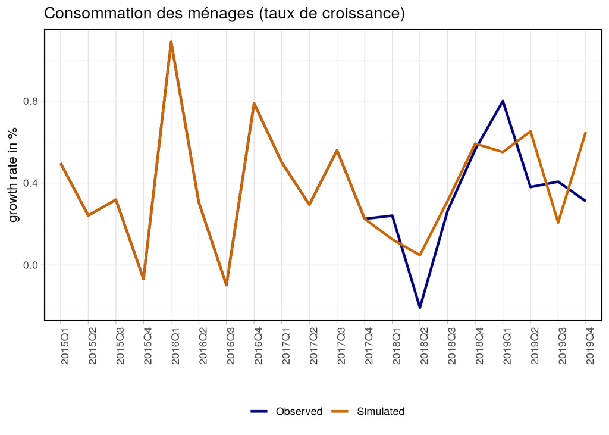

```r
graph_sim_obs(simule,start_plot = as.Date("2015-01-01"),title = "Consommation des ménages (taux de croissance)",type = "g")
```

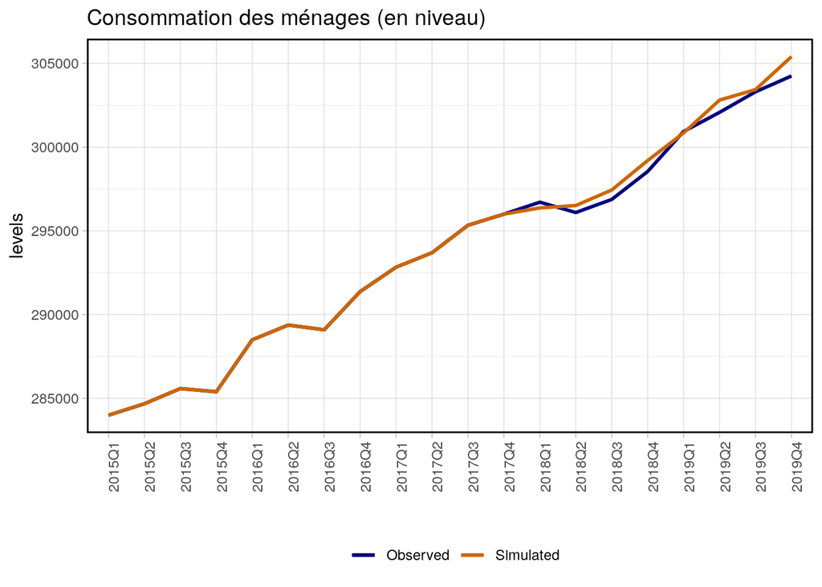

```r
graph_sim_obs(simule,start_plot = as.Date("2015-01-01"),title = "Consommation des ménages (en niveau)",type = "lvl")
```

## 4.4 Contributions dynamiques

Comme l’équation est de type MCE[^3] (modèle à correction d’erreur) et qu’elle est écrite suffisament simplement (notamment en évitant les composées de fonctions et de variables), la fonction `dyn_contrib()` peut calculer automatiquement les contributions dynamiques des variables. Cela permet de mieux apprécier les effets des variables explicatives dont l’impact peut subsister sur plusieurs périodes (du fait de leur présence avec retard dans les équations notamment). `graph_contrib()` permet de visualiser ces contributions calculées par la fonction.

```r
contribs_trim <- dyn_contribs(conso_m,database = donnees_completes,
                               start_sim = as.Date("1995-01-01"), end_sim = T42019,
                               residual_var = "p3m_d7_ch_residu")
```

```
##
##  Verifications
## Contributions: -0.000001 0 0 0 0 0 0 0 0 0 0 0 0 0 0 0 0 0 0 0 0 0 0 0 0 0 0 0 0 0 0 0 0 0 0 0 0 0 0 0 0 0 0 0 0 0 0 0 0 0 0
##  Verifications
## Residuals: -0.000001 0 0 0 0 0 0 0 0 0 0 0 0 0 0 0 0 0 0 0 0 0 0 0 0 0 0 0 0 0 0 0 0 0 0 0 0 0 0 0 0 0 0 0 0 0 0 0 0 0 0
```

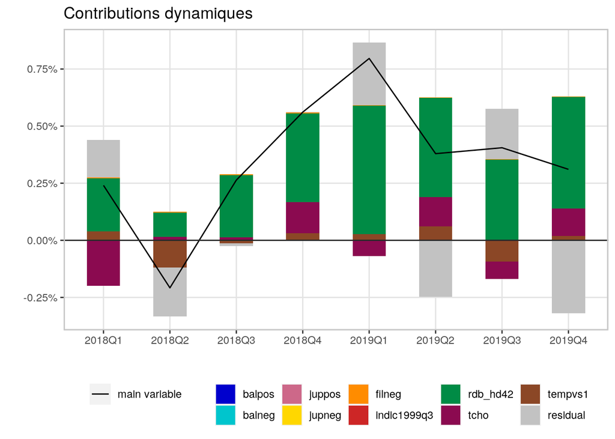

```r
graph_contrib(contribs_trim, start_plot = T12018, index_time = "date")
```

*A noter que pour obtenir des contributions dynamiques qui somment, il convient de renseigner une plage de périodes la plus large possible, cela améliore la qualité des résultats sur les périodes les plus récentes.*

On remarque que l’équation de consommation contient beaucoup d’indicatrices, il peut être pertinent de regrouper leurs contributions. L’exemple ci-dessous présente plus de personnalisation du graphique :

```r
contribs_trim <- dyn_contribs(conso_m,database = donnees_completes,
                               start_sim = as.Date("1990-01-01"), end_sim = T42019,
                               residual_var = "p3m_d7_ch_residu",
                               regroup_these = c("balpos","balneg","juppos","jupneg","filneg","indic1999q3"),
                               name_group = "indicatrices")
```

```
##
##  Verifications
## Contributions: 0 0 0 0 0 0 0 0 0 0 0 0 0 0 0 0 0 0 0 0 0 0 0 0 0 0 0 0 0 0 0 0 0 0 0 0 0 0 0 0 0 0 0 0 0 0 0 0 0 0 0
##  Verifications
## Residuals: 0 0 0 0 0 0 0 0 0 0 0 0 0 0 0 0 0 0 0 0 0 0 0 0 0 0 0 0 0 0 0 0 0 0 0 0 0 0 0 0 0 0 0 0 0 0 0 0 0 0 0
```

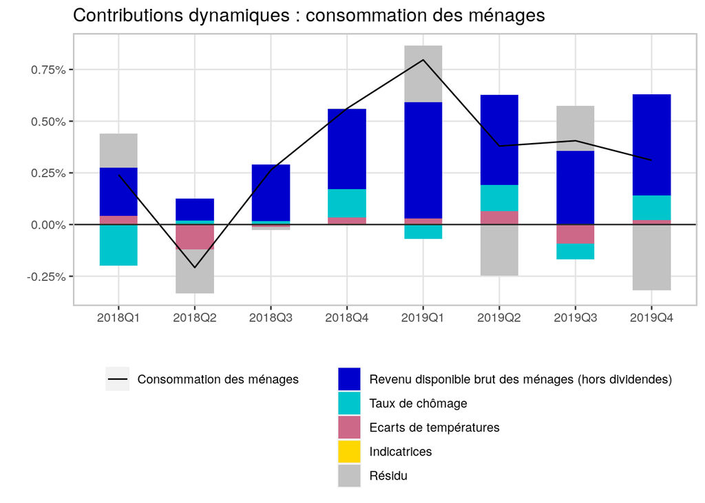

```r
graph_contrib(contribs_trim, start_plot = T12018, index_time = "date",
              title = "Contributions dynamiques : consommation des ménages",
              name_endogenous = "Consommation des ménages",
              bar_labels = c("Revenu disponible brut des ménages (hors dividendes)", "Taux de chômage",
                             "Ecarts de températures", "Indicatrices", "Résidu"),legend_n_row = 5)
```

Les données sont trimestrielles, les contributions peuvent être annualisées par la fonction `yearly_contrib()`. La fonction `graph_contrib()` fonctionne également avec :

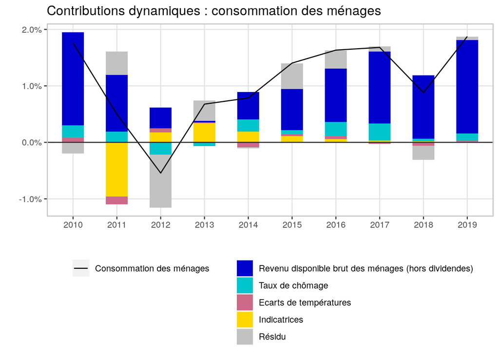

```r
contribs_ann <- yearly_contrib(contribs_trim , index_year = as.numeric(format(contribs_trim$date,"%Y")))
graph_contrib(contribs_ann, start_plot = 2010, index_time = "date",
              title = "Contributions dynamiques : consommation des ménages",
              name_endogenous = "Consommation des ménages",
              bar_labels = c("Revenu disponible brut des ménages (hors dividendes)", "Taux de chômage",
                             "Ecarts de températures", "Indicatrices", "Résidu"),legend_n_row = 5)
```

[^1]: La fonction `system.file()` de R permet de générer un chemin d’accès vers des fichiers contenus dans un package installé.
[^2]: Généralement, en prévision ces données ne sont pas disponibles. Le prévionniste émet alors des hypothèses sur l’évolution de celles-ci ainsi que sur les variables résiduelles pour pouvoir calculer les endogènes par le modèle et établir ainsi des scénarios de prévision.
[^3]: Les contributions dynamiques peuvent fonctionner pour d’autres types d’équation, mais des ajustement peuvent être nécessaires (au niveau des sorties et/ou de la formule) pour retrouver des résultats interprétables.